# 18.1 Crime and punishment

The data in linearRegression_crimePunishment.csv contains the murder rate per capita and the rate of automobile crimes per 100,000 individuals (both on the log scale) in the ten US States that have changed their legislation on capital punishment since 1960 (in all cases the states abolished capital punishment). We also include a dummy variable (“law”) that is 1 if the state allows capital punishment in that year, and 0 otherwise. The crime data is from http://www.disastercenter.com.

# Problem 18.1.1.

Graph the data and comment on any trends.

```r
crime_data <- read.csv('linearRegression_crimePunishment.csv')
crime_data
```

| X | year | stateName | murder | car | law | state |
| --- | --- | --- | --- | --- | --- | --- |
| 1 | 1960 | Connecticut | 0.47000363 | 4.865224 | 1 | 1 |
| 2 | 1961 | Connecticut | 0.00000000 | 4.873669 | 1 | 1 |
| 3 | 1962 | Connecticut | 0.26236426 | 4.984976 | 1 | 1 |
| 4 | 1963 | Connecticut | 0.58778666 | 5.214392 | 1 | 1 |
| 5 | 1964 | Connecticut | 0.58778666 | 5.331268 | 1 | 1 |
| 6 | 1965 | Connecticut | 0.47000363 | 5.381739 | 1 | 1 |
| 7 | 1966 | Connecticut | 0.69314718 | 5.522660 | 1 | 1 |
| 8 | 1967 | Connecticut | 0.87546874 | 5.771753 | 1 | 1 |
| 9 | 1968 | Connecticut | 0.91629073 | 5.929855 | 1 | 1 |
| 10 | 1969 | Connecticut | 1.06471074 | 6.058656 | 1 | 1 |

[output cut: 530 more lines]

```r
library(tidyverse)
```

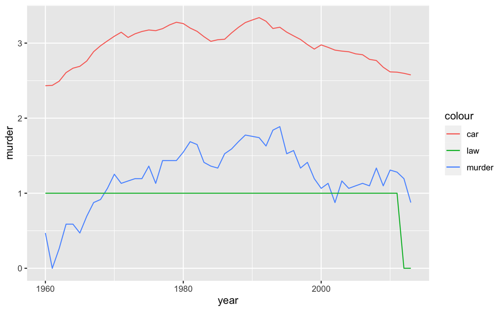

```r
ggplot(data=filter(crime_data, stateName=='Connecticut'), aes(year)) + geom_line(aes(y=murder, color="murder")) + geom_line(aes(y=car/2, color="car")) + geom_line(aes(y=law, color='law'))
```

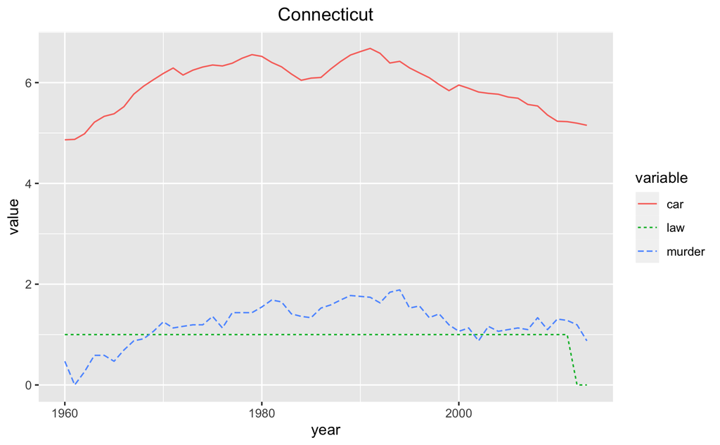

```r
df <- filter(crime_data, stateName=='Connecticut') %>%
  select(year, murder, car, law) %>%
  gather(key="variable", value = "value", -year)

ggplot(df, aes(x=year, y=value)) +
  geom_line(aes(color=variable, linetype=variable)) + ggtitle("Connecticut") + theme(plot.title = element_text(hjust = 0.5))
```

```r
NA
NA
```

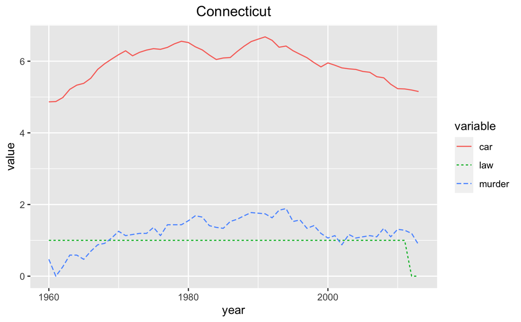

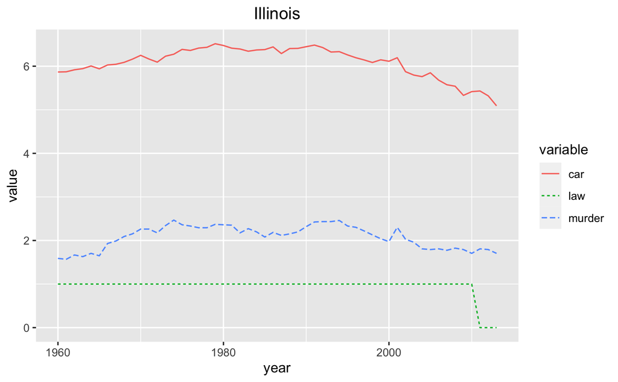

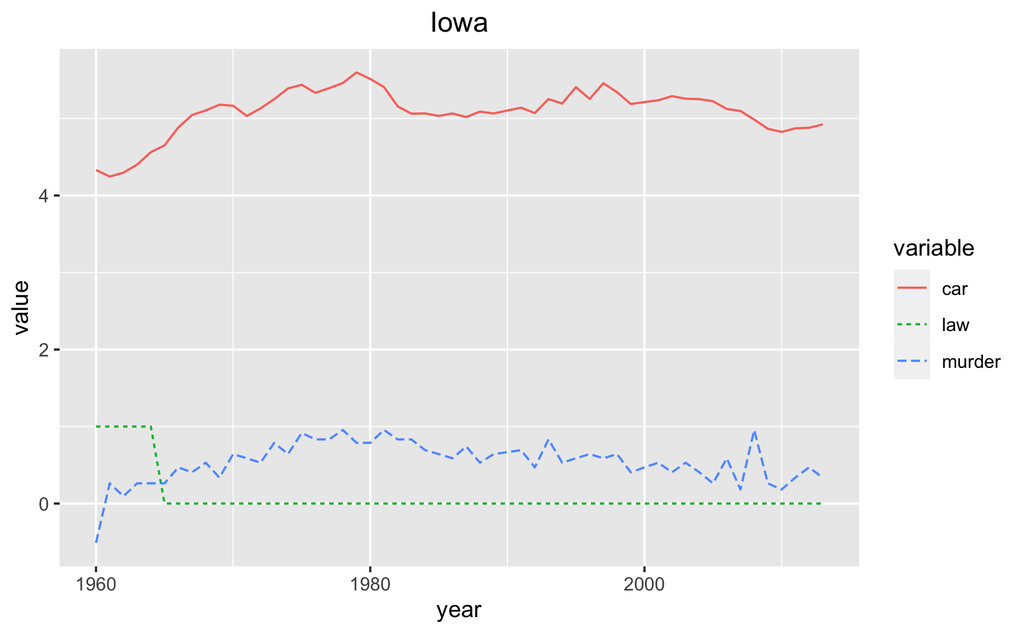

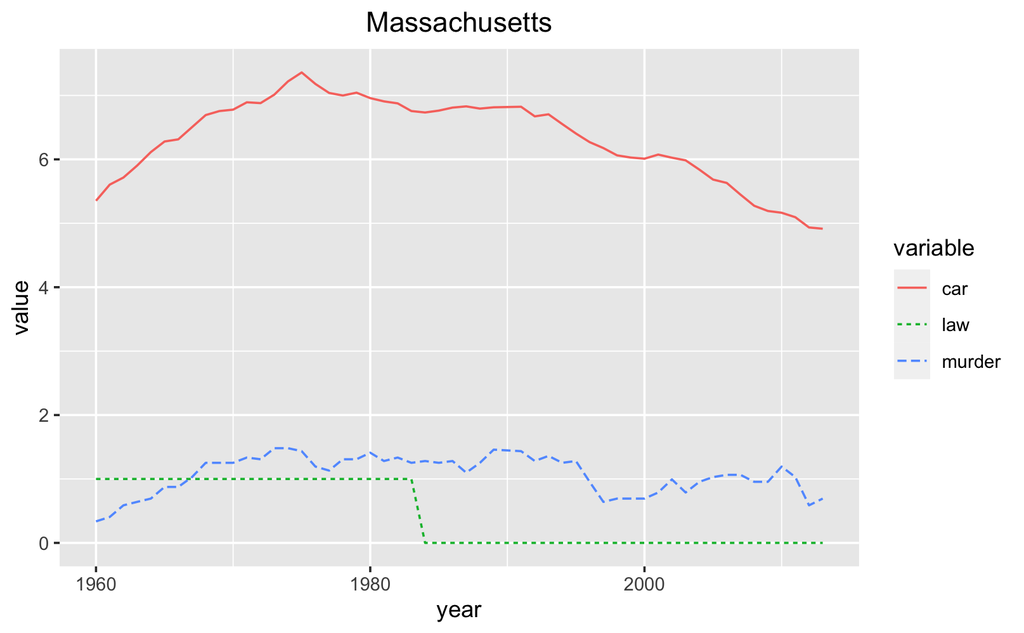

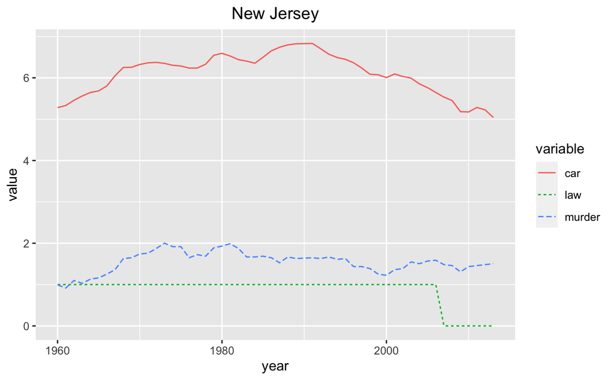

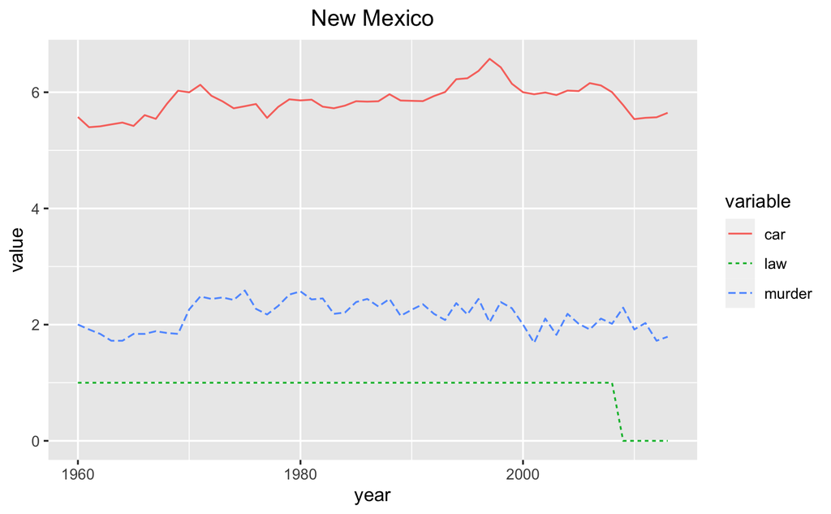

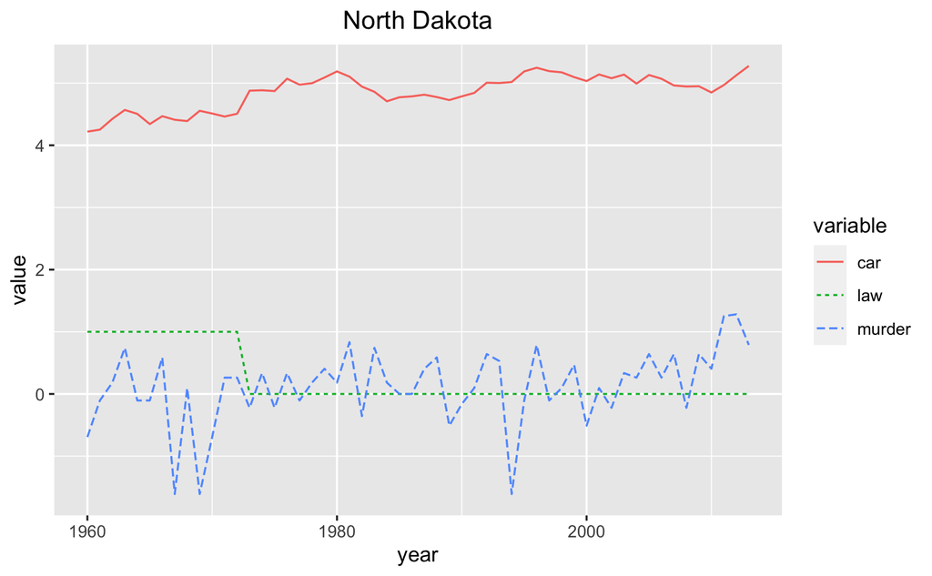

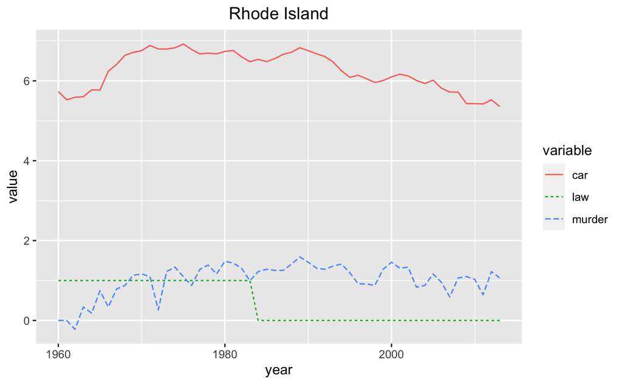

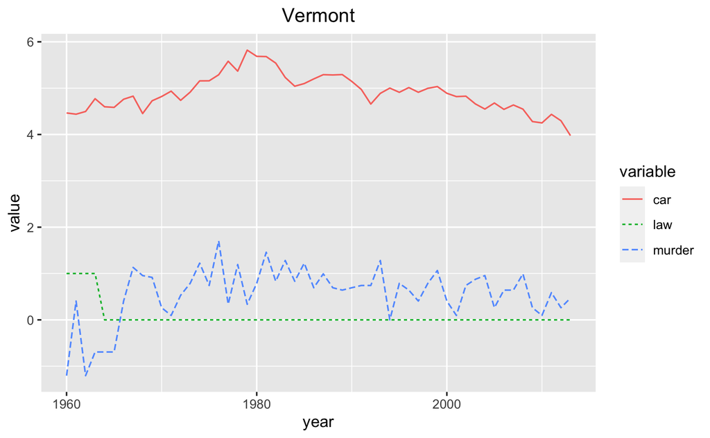

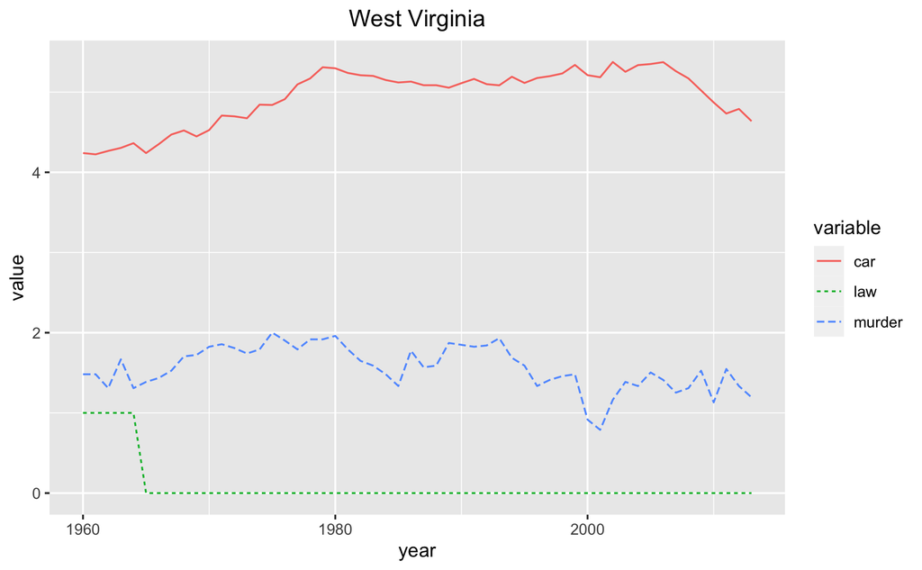

```r
for (lstate in unique(crime_data$stateName)){
  df <- filter(crime_data, crime_data$stateName == lstate) %>%
  select(year, murder, car, law) %>%
  gather(key="variable", value = "value", -year)

  print(ggplot(df, aes(x=year, y=value)) +
  geom_line(aes(color=variable, linetype=variable)) +  ggtitle(lstate) + theme(plot.title = element_text(hjust = 0.5)))

}
```

# Problem 18.1.2.

A simple model for murder rates is of the form,

```
        murderi,t ∼ N (α + βpenaltyi,t + γcari,t, σ) (18.1)
```

where we assume that the effect of having the death penalty is given by β, which is assumed to be the same across all states. We include cari,t – a measure of crimes on automobiles, as an independent variable to proxy for the contemporaneous underlying level of crime. Estimate this model and hence determine whether the death penalty acts as a deterrent to murder.

```r
library(rstan)
options(mc.cores = parallel::detectCores())
```

```r
dataList <- list(N = 540, murder = crime_data$murder, car = crime_data$car,
                 law = crime_data$law, state = crime_data$state)
```

```r
fit <- stan(file = 'Model_Problem_18_1.stan', data = dataList, iter=1000, chains=4, seed=42)
```

```
starting worker pid=70096 on localhost:11531 at 21:01:39.975
starting worker pid=70110 on localhost:11531 at 21:01:40.911
starting worker pid=70124 on localhost:11531 at 21:01:41.251
starting worker pid=70138 on localhost:11531 at 21:01:41.553
```

```r
print(fit)
```

```
Inference for Stan model: Model_Problem_18_1.
4 chains, each with iter=1000; warmup=500; thin=1;
post-warmup draws per chain=500, total post-warmup draws=2000.

        mean se_mean   sd   2.5%    25%    50%    75%  97.5% n_eff Rhat
alpha  -1.48    0.01 0.22  -1.91  -1.63  -1.48  -1.34  -1.05   784    1
beta    0.24    0.00 0.06   0.12   0.20   0.24   0.28   0.35  1170    1
gamma   0.45    0.00 0.04   0.37   0.43   0.45   0.48   0.53   781    1
sigma   0.62    0.00 0.02   0.59   0.61   0.62   0.64   0.66  1200    1
lp__  -16.05    0.05 1.32 -19.24 -16.77 -15.77 -15.06 -14.38   826    1

Samples were drawn using NUTS(diag_e) at Tue Sep  8 21:02:04 2020.
For each parameter, n_eff is a crude measure of effective sample size,
and Rhat is the potential scale reduction factor on split chains (at
convergence, Rhat=1).
```

*Where we see that we estimate that the imposition of the death penalty on average raises the murder rate by on average 24%!*

# Problem 18.1.3.

An alternative model allows there to be state-level effects,

```
    murderi,t ∼ N (αi + βipenaltyi,t + γicari,t, σi) , (18.2)
```

where we assume that αi ∼ N(α ̄,σα), βi ∼ N(β ̄,σβ) and γi ∼ N(γ ̄,σγ) (we assume fully heteroge- neous estimates for σ). Estimate the above model and compare the results with the homogeneous coefficient model.

```r
K = length(unique(crime_data$stateName))
K
```

```
[1] 10
```

```r
dataList <- list(N = 540, K = length(unique(crime_data$stateName)), murder = crime_data$murder, car = crime_data$car, law = crime_data$law, state = crime_data$state)
```

```r
fit_hetrogenous <- stan(file = 'Model_Hetrogeneous_Prob_18_1.stan', data = dataList, iter=1000, chains=4, seed=42)
```

```
starting worker pid=70271 on localhost:11531 at 21:04:21.986
starting worker pid=70285 on localhost:11531 at 21:04:23.148
starting worker pid=70299 on localhost:11531 at 21:04:24.753
starting worker pid=70313 on localhost:11531 at 21:04:25.987
```

```r
print(fit_hetrogenous)
```

```
Inference for Stan model: Model_Hetrogeneous_Prob_18_1.
4 chains, each with iter=1000; warmup=500; thin=1;
post-warmup draws per chain=500, total post-warmup draws=2000.

                mean se_mean   sd   2.5%    25%    50%    75%  97.5% n_eff Rhat
alpha[1]       -2.18    0.01 0.37  -2.92  -2.43  -2.16  -1.92  -1.45   699 1.00
alpha[2]       -1.61    0.01 0.37  -2.36  -1.85  -1.61  -1.36  -0.91   903 1.00
alpha[3]       -1.89    0.01 0.47  -2.84  -2.19  -1.89  -1.58  -0.97  1124 1.00
alpha[4]       -1.35    0.01 0.26  -1.88  -1.51  -1.34  -1.18  -0.83   864 1.00
alpha[5]       -1.14    0.01 0.29  -1.69  -1.34  -1.14  -0.95  -0.57  1284 1.00
alpha[6]       -0.61    0.02 0.54  -1.62  -0.97  -0.63  -0.27   0.51  1020 1.00
alpha[7]       -1.85    0.02 0.58  -2.97  -2.22  -1.88  -1.50  -0.62  1055 1.00
alpha[8]       -2.11    0.01 0.43  -2.97  -2.41  -2.11  -1.83  -1.27  1133 1.00
alpha[9]       -1.60    0.02 0.51  -2.58  -1.93  -1.62  -1.29  -0.54   988 1.00
alpha[10]       0.16    0.04 0.75  -1.11  -0.40   0.12   0.68   1.70   409 1.01
beta[1]        -0.32    0.00 0.16  -0.63  -0.42  -0.32  -0.22  -0.02  2345 1.00
beta[2]        -0.22    0.00 0.10  -0.43  -0.30  -0.22  -0.15  -0.02  1755 1.00
beta[3]        -0.14    0.00 0.11  -0.36  -0.22  -0.14  -0.07   0.09  1593 1.00
beta[4]        -0.16    0.00 0.06  -0.27  -0.20  -0.16  -0.13  -0.05  2455 1.00
beta[5]        -0.35    0.00 0.09  -0.52  -0.41  -0.35  -0.29  -0.18  1834 1.00
beta[6]         0.05    0.00 0.12  -0.18  -0.03   0.05   0.14   0.28  2340 1.00
beta[7]        -0.22    0.00 0.17  -0.56  -0.33  -0.22  -0.11   0.10  2140 1.00
beta[8]        -0.46    0.00 0.08  -0.61  -0.51  -0.46  -0.41  -0.31  2684 1.00
beta[9]        -0.78    0.01 0.25  -1.27  -0.95  -0.77  -0.61  -0.30   935 1.00
beta[10]        0.01    0.01 0.16  -0.29  -0.09   0.01   0.12   0.33   837 1.00
gamma[1]        0.62    0.00 0.06   0.50   0.58   0.62   0.67   0.75   771 1.00
gamma[2]        0.64    0.00 0.07   0.51   0.60   0.64   0.69   0.78   832 1.00
gamma[3]        0.48    0.00 0.09   0.30   0.42   0.48   0.54   0.66  1137 1.00
gamma[4]        0.39    0.00 0.04   0.31   0.37   0.39   0.42   0.48   888 1.00
gamma[5]        0.49    0.00 0.05   0.38   0.45   0.49   0.53   0.59  1177 1.00
gamma[6]        0.46    0.00 0.09   0.26   0.40   0.47   0.52   0.64  1038 1.00
gamma[7]        0.42    0.00 0.12   0.18   0.35   0.42   0.49   0.64  1072 1.00
gamma[8]        0.53    0.00 0.07   0.39   0.49   0.53   0.58   0.68  1127 1.00
gamma[9]        0.46    0.00 0.10   0.24   0.39   0.46   0.52   0.65   980 1.00
gamma[10]       0.28    0.01 0.15  -0.02   0.18   0.29   0.39   0.54   412 1.01
sigma[1]        0.24    0.00 0.02   0.20   0.22   0.24   0.26   0.29  2945 1.00
sigma[2]        0.16    0.00 0.02   0.13   0.15   0.16   0.17   0.20  2694 1.00
sigma[3]        0.20    0.00 0.02   0.16   0.18   0.19   0.21   0.23  2106 1.00
sigma[4]        0.20    0.00 0.02   0.17   0.19   0.20   0.21   0.24  3026 1.00
sigma[5]        0.18    0.00 0.02   0.15   0.17   0.18   0.19   0.22  2442 1.00
sigma[6]        0.25    0.00 0.03   0.20   0.23   0.25   0.26   0.30  2797 1.00
sigma[7]        0.58    0.00 0.06   0.48   0.54   0.58   0.62   0.71  2534 1.00
sigma[8]        0.28    0.00 0.03   0.23   0.26   0.28   0.30   0.34  2448 1.00
sigma[9]        0.48    0.00 0.05   0.40   0.45   0.48   0.52   0.59  1872 1.00
sigma[10]       0.30    0.00 0.03   0.25   0.28   0.30   0.32   0.37  1030 1.00
alpha_top      -1.31    0.01 0.35  -1.93  -1.54  -1.33  -1.11  -0.52  1002 1.00
alpha_sigma     0.90    0.01 0.33   0.37   0.66   0.85   1.09   1.68   541 1.00
beta_top       -0.26    0.00 0.11  -0.48  -0.32  -0.25  -0.19  -0.03  1165 1.00
beta_sigma      0.31    0.00 0.12   0.13   0.23   0.29   0.37   0.60   926 1.01
gamma_top       0.48    0.00 0.06   0.34   0.44   0.48   0.52   0.60  1112 1.00
gamma_sigma     0.15    0.00 0.07   0.06   0.10   0.14   0.18   0.33   524 1.00
alpha_average  -1.29    0.02 1.02  -3.17  -1.93  -1.36  -0.70   0.85  1689 1.00
beta_average   -0.26    0.01 0.35  -0.98  -0.46  -0.25  -0.05   0.44  1926 1.00
gamma_average   0.48    0.00 0.18   0.10   0.39   0.48   0.58   0.84  1891 1.00
lp__          458.70    0.24 5.29 447.51 455.27 459.04 462.38 468.38   497 1.01

Samples were drawn using NUTS(diag_e) at Tue Sep  8 21:06:54 2020.
For each parameter, n_eff is a crude measure of effective sample size,
and Rhat is the potential scale reduction factor on split chains (at
convergence, Rhat=1).
```

With a mean effect size of a 26% reduction in murder rates although with a much wider range of effects.

# Problem extra. (Not in main text but wanted to include)

Another model allows there to be time trends in the data, murderi,t ∼ N (αi + δit + βipenaltyi,t + γicari,t, σi) , (18.3) where δi ∼ N(δ ̄,σδ).

Again estimate this model and compare the effect size of the death penalty across the three models.

```r
fit_time_trends <- stan(file = 'Model_timeTrends_Prob_18_1.stan', data = dataList, iter=1000, chains=4, seed=42)
```

```
starting worker pid=70507 on localhost:11531 at 21:08:05.000
starting worker pid=70521 on localhost:11531 at 21:08:05.357
starting worker pid=70535 on localhost:11531 at 21:08:05.708
starting worker pid=70549 on localhost:11531 at 21:08:06.077
```

```
There were 15 divergent transitions after warmup. See
http://mc-stan.org/misc/warnings.html#divergent-transitions-after-warmup
to find out why this is a problem and how to eliminate them.Examine the pairs() plot to diagnose sampling problems
Bulk Effective Samples Size (ESS) is too low, indicating posterior means and medians may be unreliable.
Running the chains for more iterations may help. See
http://mc-stan.org/misc/warnings.html#bulk-essTail Effective Samples Size (ESS) is too low, indicating posterior variances and tail quantiles may be unreliable.
Running the chains for more iterations may help. See
http://mc-stan.org/misc/warnings.html#tail-ess
```

```r
print(fit_time_trends)
```

```
Inference for Stan model: Model_timeTrends_Prob_18_1.
4 chains, each with iter=1000; warmup=500; thin=1;
post-warmup draws per chain=500, total post-warmup draws=2000.

                mean se_mean    sd   2.5%    25%    50%    75%  97.5% n_eff Rhat
alpha[1]       -2.22    0.02  0.44  -3.06  -2.51  -2.22  -1.93  -1.35   499 1.00
alpha[2]       -1.92    0.03  0.52  -2.86  -2.26  -1.95  -1.60  -0.79   338 1.01
alpha[3]       -2.01    0.03  0.61  -3.16  -2.39  -2.05  -1.65  -0.71   364 1.00
alpha[4]       -1.80    0.04  0.66  -2.96  -2.24  -1.87  -1.43  -0.24   241 1.01
alpha[5]       -1.76    0.05  0.73  -3.00  -2.24  -1.84  -1.35  -0.12   249 1.01
alpha[6]       -1.58    0.06  0.87  -2.93  -2.15  -1.75  -1.15   0.48   200 1.01
alpha[7]       -1.97    0.04  0.80  -3.34  -2.44  -2.05  -1.57  -0.19   314 1.00
alpha[8]       -2.08    0.05  0.83  -3.66  -2.54  -2.12  -1.65  -0.26   246 1.00
alpha[9]       -1.93    0.05  0.84  -3.36  -2.42  -2.02  -1.51   0.03   243 1.01
alpha[10]      -1.49    0.08  1.02  -2.94  -2.14  -1.70  -1.03   0.93   182 1.02
beta[1]        -0.33    0.00  0.15  -0.63  -0.43  -0.33  -0.23  -0.03  1944 1.00
beta[2]        -0.25    0.00  0.10  -0.45  -0.32  -0.25  -0.17  -0.05  1768 1.00
beta[3]        -0.15    0.00  0.11  -0.36  -0.22  -0.15  -0.08   0.05  1871 1.00
beta[4]        -0.17    0.00  0.06  -0.28  -0.20  -0.17  -0.13  -0.05  2276 1.00
beta[5]        -0.35    0.00  0.09  -0.53  -0.41  -0.35  -0.29  -0.17  2009 1.00
beta[6]         0.05    0.00  0.11  -0.19  -0.03   0.05   0.12   0.27  1704 1.00
beta[7]        -0.23    0.00  0.17  -0.57  -0.34  -0.23  -0.12   0.10  1617 1.00
beta[8]        -0.46    0.00  0.08  -0.63  -0.52  -0.47  -0.41  -0.30  1713 1.00
beta[9]        -0.75    0.01  0.26  -1.29  -0.93  -0.73  -0.56  -0.26  1034 1.00
beta[10]       -0.08    0.00  0.15  -0.37  -0.18  -0.09   0.02   0.24  1049 1.00
gamma[1]        0.63    0.00  0.06   0.50   0.58   0.63   0.67   0.76   521 1.01
gamma[2]        0.67    0.00  0.07   0.54   0.63   0.67   0.72   0.79   911 1.00
gamma[3]        0.47    0.00  0.09   0.32   0.42   0.47   0.53   0.65  1515 1.00
gamma[4]        0.39    0.00  0.04   0.31   0.36   0.39   0.42   0.48  1800 1.00
gamma[5]        0.49    0.00  0.06   0.38   0.45   0.49   0.53   0.60  1661 1.00
gamma[6]        0.44    0.00  0.10   0.22   0.37   0.44   0.51   0.63  1043 1.00
gamma[7]        0.40    0.01  0.15   0.08   0.30   0.40   0.50   0.70   937 1.00
gamma[8]        0.54    0.00  0.08   0.39   0.49   0.55   0.60   0.70  1005 1.00
gamma[9]        0.44    0.00  0.13   0.19   0.36   0.45   0.53   0.69  1654 1.00
gamma[10]       0.13    0.01  0.15  -0.14   0.03   0.13   0.23   0.42   439 1.00
delta[1]        0.04    0.01  0.23  -0.50  -0.07   0.07   0.17   0.41   452 1.01
delta[2]        0.08    0.01  0.20  -0.37  -0.03   0.09   0.20   0.43   343 1.01
delta[3]        0.05    0.01  0.19  -0.40  -0.05   0.07   0.17   0.39   314 1.01
delta[4]        0.11    0.01  0.16  -0.26   0.02   0.12   0.22   0.41   260 1.01
delta[5]        0.13    0.01  0.15  -0.20   0.04   0.13   0.23   0.38   259 1.01
```

[output cut: 18 more lines]

```
beta_sigma      0.29    0.00  0.12   0.12   0.21   0.27   0.36   0.58  1007 1.01
gamma_top       0.46    0.00  0.08   0.31   0.41   0.46   0.51   0.60  1519 1.00
gamma_sigma     0.20    0.00  0.08   0.08   0.14   0.19   0.24   0.40   665 1.00
delta_top       0.09    0.01  0.13  -0.22   0.02   0.10   0.17   0.31   215 1.01
delta_sigma     0.15    0.01  0.09   0.01   0.09   0.14   0.19   0.38   206 1.02
alpha_average  -1.81    0.04  0.86  -3.23  -2.34  -1.91  -1.36   0.04   379 1.01
beta_average   -0.28    0.01  0.33  -0.94  -0.47  -0.27  -0.08   0.34  1885 1.00
gamma_average   0.46    0.01  0.23   0.01   0.34   0.46   0.58   0.94  1847 1.00
delta_average   0.09    0.01  0.23  -0.39  -0.02   0.09   0.21   0.51   443 1.01
lp__          479.83    0.94 10.33 459.97 472.90 479.49 486.42 500.59   122 1.02

Samples were drawn using NUTS(diag_e) at Tue Sep  8 21:09:18 2020.
For each parameter, n_eff is a crude measure of effective sample size,
and Rhat is the potential scale reduction factor on split chains (at
convergence, Rhat=1).
```

## Fixing divergent iterations

Let’s try by increasing control = list(adapt_delta = 0.9)

```r
fit_time_trends_2 <- stan(file = 'Model_timeTrends_Prob_18_1.stan', data = dataList, iter=1000, chains=4, control = list(adapt_delta = 0.9), seed=42)
```

```
starting worker pid=70929 on localhost:11531 at 21:19:24.327
starting worker pid=70943 on localhost:11531 at 21:19:24.677
starting worker pid=70957 on localhost:11531 at 21:19:25.046
starting worker pid=70971 on localhost:11531 at 21:19:25.406
```

```
There were 7 divergent transitions after warmup. See
http://mc-stan.org/misc/warnings.html#divergent-transitions-after-warmup
to find out why this is a problem and how to eliminate them.Examine the pairs() plot to diagnose sampling problems
Bulk Effective Samples Size (ESS) is too low, indicating posterior means and medians may be unreliable.
Running the chains for more iterations may help. See
http://mc-stan.org/misc/warnings.html#bulk-essTail Effective Samples Size (ESS) is too low, indicating posterior variances and tail quantiles may be unreliable.
Running the chains for more iterations may help. See
http://mc-stan.org/misc/warnings.html#tail-ess
```

```r
print(fit_time_trends_2)
```

```
Inference for Stan model: Model_timeTrends_Prob_18_1.
4 chains, each with iter=1000; warmup=500; thin=1;
post-warmup draws per chain=500, total post-warmup draws=2000.

                mean se_mean   sd   2.5%    25%    50%    75%  97.5% n_eff Rhat
alpha[1]       -2.19    0.02 0.44  -3.05  -2.49  -2.19  -1.90  -1.31   459 1.01
alpha[2]       -1.87    0.03 0.51  -2.84  -2.21  -1.89  -1.56  -0.78   358 1.01
alpha[3]       -1.98    0.04 0.63  -3.19  -2.36  -1.99  -1.61  -0.69   280 1.02
alpha[4]       -1.73    0.04 0.66  -2.93  -2.16  -1.78  -1.33  -0.32   230 1.02
alpha[5]       -1.69    0.05 0.73  -2.98  -2.16  -1.76  -1.24  -0.07   257 1.01
alpha[6]       -1.49    0.06 0.85  -2.88  -2.07  -1.61  -1.00   0.45   205 1.02
alpha[7]       -1.92    0.05 0.80  -3.46  -2.38  -1.95  -1.48  -0.24   293 1.02
alpha[8]       -2.04    0.05 0.80  -3.62  -2.51  -2.07  -1.58  -0.31   269 1.02
alpha[9]       -1.87    0.05 0.81  -3.37  -2.36  -1.92  -1.45  -0.08   305 1.02
alpha[10]      -1.36    0.08 1.12  -3.00  -2.08  -1.59  -0.87   1.43   196 1.02
beta[1]        -0.33    0.00 0.15  -0.64  -0.43  -0.33  -0.23  -0.05  2243 1.00
beta[2]        -0.24    0.00 0.10  -0.43  -0.31  -0.24  -0.18  -0.04  1994 1.00
beta[3]        -0.15    0.00 0.11  -0.37  -0.22  -0.15  -0.08   0.06  1487 1.00
beta[4]        -0.16    0.00 0.06  -0.27  -0.20  -0.17  -0.13  -0.05  2613 1.00
beta[5]        -0.34    0.00 0.09  -0.51  -0.40  -0.35  -0.29  -0.17  2158 1.00
beta[6]         0.05    0.00 0.12  -0.20  -0.03   0.05   0.13   0.27  1756 1.00
beta[7]        -0.23    0.00 0.16  -0.54  -0.33  -0.23  -0.13   0.10  2339 1.00
beta[8]        -0.46    0.00 0.08  -0.63  -0.52  -0.47  -0.41  -0.30  2448 1.00
beta[9]        -0.73    0.01 0.26  -1.24  -0.91  -0.72  -0.55  -0.27  1069 1.00
beta[10]       -0.07    0.00 0.16  -0.36  -0.18  -0.08   0.03   0.25  1186 1.00
gamma[1]        0.62    0.00 0.06   0.49   0.58   0.62   0.67   0.74   881 1.00
gamma[2]        0.67    0.00 0.06   0.54   0.62   0.67   0.71   0.79  1031 1.00
gamma[3]        0.48    0.00 0.09   0.30   0.42   0.48   0.53   0.65  1158 1.00
gamma[4]        0.39    0.00 0.04   0.31   0.36   0.39   0.42   0.48  1927 1.00
gamma[5]        0.49    0.00 0.06   0.37   0.45   0.49   0.52   0.60  1811 1.00
gamma[6]        0.44    0.00 0.11   0.22   0.37   0.44   0.51   0.65  1459 1.00
gamma[7]        0.41    0.00 0.15   0.11   0.31   0.41   0.50   0.72  1381 1.00
gamma[8]        0.55    0.00 0.08   0.40   0.50   0.55   0.60   0.70  1389 1.00
gamma[9]        0.46    0.00 0.12   0.22   0.37   0.46   0.53   0.70  1322 1.00
gamma[10]       0.14    0.01 0.15  -0.14   0.03   0.14   0.24   0.44   542 1.01
delta[1]        0.02    0.01 0.23  -0.54  -0.09   0.04   0.15   0.45   358 1.01
delta[2]        0.06    0.01 0.20  -0.38  -0.05   0.07   0.18   0.45   312 1.02
delta[3]        0.04    0.01 0.19  -0.36  -0.07   0.05   0.15   0.37   281 1.01
delta[4]        0.10    0.01 0.16  -0.23   0.00   0.10   0.20   0.42   234 1.02
delta[5]        0.11    0.01 0.15  -0.19   0.02   0.12   0.21   0.38   240 1.02
```

[output cut: 18 more lines]

```
beta_sigma      0.29    0.00 0.11   0.12   0.21   0.27   0.34   0.56   973 1.00
gamma_top       0.46    0.00 0.08   0.30   0.41   0.47   0.51   0.62  1082 1.01
gamma_sigma     0.20    0.00 0.08   0.08   0.14   0.19   0.24   0.39   619 1.00
delta_top       0.07    0.01 0.13  -0.21   0.00   0.08   0.15   0.32   233 1.02
delta_sigma     0.15    0.01 0.08   0.01   0.09   0.14   0.19   0.33   206 1.01
alpha_average  -1.74    0.05 0.90  -3.33  -2.29  -1.85  -1.28   0.28   399 1.01
beta_average   -0.26    0.01 0.33  -0.91  -0.45  -0.26  -0.08   0.43  2065 1.00
gamma_average   0.47    0.01 0.23   0.00   0.34   0.48   0.60   0.89  1875 1.00
delta_average   0.07    0.01 0.22  -0.39  -0.05   0.07   0.19   0.50   592 1.01
lp__          479.45    0.87 9.70 461.96 473.17 479.03 484.93 501.69   125 1.03

Samples were drawn using NUTS(diag_e) at Tue Sep  8 21:20:53 2020.
For each parameter, n_eff is a crude measure of effective sample size,
and Rhat is the potential scale reduction factor on split chains (at
convergence, Rhat=1).
```

Lets try now further increasing step size from 0.9 to 0.95

```r
fit_time_trends_3 <- stan(file = 'Model_timeTrends_Prob_18_1.stan', data = dataList, iter=1000, chains=4, control = list(adapt_delta = 0.95), seed=42)
```

```
starting worker pid=71039 on localhost:11531 at 21:23:03.490
starting worker pid=71053 on localhost:11531 at 21:23:03.883
starting worker pid=71067 on localhost:11531 at 21:23:04.219
starting worker pid=71081 on localhost:11531 at 21:23:04.592
```

```
There were 5 divergent transitions after warmup. See
http://mc-stan.org/misc/warnings.html#divergent-transitions-after-warmup
to find out why this is a problem and how to eliminate them.Examine the pairs() plot to diagnose sampling problems
Bulk Effective Samples Size (ESS) is too low, indicating posterior means and medians may be unreliable.
Running the chains for more iterations may help. See
http://mc-stan.org/misc/warnings.html#bulk-essTail Effective Samples Size (ESS) is too low, indicating posterior variances and tail quantiles may be unreliable.
Running the chains for more iterations may help. See
http://mc-stan.org/misc/warnings.html#tail-ess
```

Still 5 divergent transitions after warmup.Lets increase iterations as well?

```r
fit_time_trends_4 <- stan(file = 'Model_timeTrends_Prob_18_1.stan', data = dataList, iter=2000, chains=4, control = list(adapt_delta = 0.95), seed=42)
```

```
starting worker pid=71356 on localhost:11531 at 21:29:30.056
starting worker pid=71370 on localhost:11531 at 21:29:30.447
starting worker pid=71384 on localhost:11531 at 21:29:31.100
starting worker pid=71398 on localhost:11531 at 21:29:31.470
```

```
There were 23 divergent transitions after warmup. See
http://mc-stan.org/misc/warnings.html#divergent-transitions-after-warmup
to find out why this is a problem and how to eliminate them.Examine the pairs() plot to diagnose sampling problems
Bulk Effective Samples Size (ESS) is too low, indicating posterior means and medians may be unreliable.
Running the chains for more iterations may help. See
http://mc-stan.org/misc/warnings.html#bulk-essTail Effective Samples Size (ESS) is too low, indicating posterior variances and tail quantiles may be unreliable.
Running the chains for more iterations may help. See
http://mc-stan.org/misc/warnings.html#tail-ess
```

Increasing no. of iteration didn’t help! Incresed the divergent iterations to 23 from 5!

Lets go back to 1000 iterations

```r
fit_time_trends_5 <- stan(file = 'Model_timeTrends_Prob_18_1.stan', data = dataList, iter=1000, chains=4, control = list(adapt_delta = 0.95), seed=42)
```

```
starting worker pid=71639 on localhost:11531 at 21:40:36.439
starting worker pid=71653 on localhost:11531 at 21:40:36.854
starting worker pid=71667 on localhost:11531 at 21:40:37.186
starting worker pid=71681 on localhost:11531 at 21:40:37.562
```

```
There were 5 divergent transitions after warmup. See
http://mc-stan.org/misc/warnings.html#divergent-transitions-after-warmup
to find out why this is a problem and how to eliminate them.Examine the pairs() plot to diagnose sampling problems
Bulk Effective Samples Size (ESS) is too low, indicating posterior means and medians may be unreliable.
Running the chains for more iterations may help. See
http://mc-stan.org/misc/warnings.html#bulk-essTail Effective Samples Size (ESS) is too low, indicating posterior variances and tail quantiles may be unreliable.
Running the chains for more iterations may help. See
http://mc-stan.org/misc/warnings.html#tail-ess
```

```r
print(fit_time_trends_5)
```

```
Inference for Stan model: Model_timeTrends_Prob_18_1.
4 chains, each with iter=1000; warmup=500; thin=1;
post-warmup draws per chain=500, total post-warmup draws=2000.

                mean se_mean    sd   2.5%    25%    50%    75%  97.5% n_eff Rhat
alpha[1]       -2.21    0.02  0.44  -3.05  -2.52  -2.21  -1.92  -1.36   329 1.01
alpha[2]       -1.91    0.04  0.53  -2.90  -2.25  -1.93  -1.57  -0.79   206 1.02
alpha[3]       -1.98    0.04  0.62  -3.16  -2.36  -1.99  -1.60  -0.69   259 1.02
alpha[4]       -1.75    0.05  0.64  -2.82  -2.19  -1.79  -1.37  -0.33   173 1.03
alpha[5]       -1.71    0.06  0.72  -2.97  -2.17  -1.77  -1.32  -0.03   170 1.02
alpha[6]       -1.52    0.07  0.91  -2.91  -2.11  -1.66  -1.03   0.52   149 1.03
alpha[7]       -1.94    0.06  0.82  -3.47  -2.43  -1.96  -1.52  -0.20   220 1.02
alpha[8]       -2.02    0.06  0.84  -3.65  -2.50  -2.03  -1.56  -0.22   195 1.03
alpha[9]       -1.90    0.06  0.81  -3.41  -2.39  -1.94  -1.46  -0.16   197 1.03
alpha[10]      -1.40    0.08  1.04  -2.91  -2.10  -1.60  -0.93   1.32   166 1.02
beta[1]        -0.33    0.00  0.16  -0.65  -0.44  -0.33  -0.23  -0.03  1968 1.00
beta[2]        -0.25    0.00  0.11  -0.46  -0.32  -0.25  -0.18  -0.03  1014 1.00
beta[3]        -0.15    0.00  0.11  -0.38  -0.22  -0.15  -0.08   0.08  1437 1.00
beta[4]        -0.17    0.00  0.06  -0.28  -0.21  -0.17  -0.13  -0.05  1774 1.00
beta[5]        -0.35    0.00  0.09  -0.51  -0.40  -0.35  -0.29  -0.18  1489 1.00
beta[6]         0.05    0.00  0.12  -0.19  -0.03   0.05   0.13   0.27  1755 1.00
beta[7]        -0.23    0.00  0.17  -0.55  -0.34  -0.23  -0.12   0.10  1522 1.00
beta[8]        -0.47    0.00  0.08  -0.61  -0.52  -0.46  -0.42  -0.31  1772 1.00
beta[9]        -0.74    0.01  0.26  -1.28  -0.91  -0.72  -0.56  -0.27   975 1.00
beta[10]       -0.08    0.00  0.15  -0.36  -0.18  -0.08   0.02   0.24   992 1.00
gamma[1]        0.63    0.00  0.07   0.50   0.58   0.62   0.67   0.76   630 1.00
gamma[2]        0.67    0.00  0.07   0.53   0.63   0.67   0.72   0.80   612 1.00
gamma[3]        0.47    0.00  0.09   0.29   0.41   0.47   0.53   0.66  1104 1.00
gamma[4]        0.39    0.00  0.04   0.31   0.36   0.40   0.42   0.48  1520 1.01
gamma[5]        0.49    0.00  0.05   0.38   0.45   0.49   0.53   0.59  1573 1.00
gamma[6]        0.44    0.00  0.10   0.24   0.37   0.44   0.51   0.63  1155 1.00
gamma[7]        0.40    0.01  0.16   0.08   0.30   0.40   0.51   0.72   729 1.00
gamma[8]        0.55    0.00  0.07   0.40   0.50   0.55   0.60   0.69  1338 1.00
gamma[9]        0.45    0.00  0.12   0.20   0.37   0.46   0.53   0.70  1119 1.00
gamma[10]       0.14    0.01  0.15  -0.15   0.04   0.13   0.24   0.43   473 1.00
delta[1]        0.04    0.01  0.23  -0.45  -0.08   0.05   0.17   0.46   289 1.01
delta[2]        0.07    0.02  0.21  -0.39  -0.05   0.08   0.20   0.45   179 1.02
delta[3]        0.04    0.01  0.20  -0.40  -0.07   0.06   0.17   0.39   261 1.02
delta[4]        0.10    0.01  0.16  -0.24   0.01   0.11   0.21   0.38   194 1.02
delta[5]        0.12    0.01  0.15  -0.21   0.03   0.12   0.21   0.39   182 1.02
```

[output cut: 18 more lines]

```
beta_sigma      0.29    0.00  0.12   0.12   0.21   0.27   0.35   0.58   673 1.00
gamma_top       0.46    0.00  0.08   0.30   0.41   0.46   0.51   0.60  1282 1.00
gamma_sigma     0.20    0.00  0.08   0.08   0.14   0.19   0.24   0.40   607 1.00
delta_top       0.08    0.01  0.13  -0.20   0.00   0.09   0.16   0.31   140 1.03
delta_sigma     0.15    0.00  0.08   0.03   0.10   0.14   0.19   0.33   289 1.02
alpha_average  -1.77    0.06  0.87  -3.23  -2.30  -1.85  -1.35   0.21   248 1.01
beta_average   -0.29    0.01  0.32  -0.98  -0.47  -0.28  -0.10   0.35  1950 1.00
gamma_average   0.46    0.01  0.22   0.02   0.33   0.47   0.59   0.90  1911 1.00
delta_average   0.08    0.01  0.21  -0.36  -0.03   0.08   0.21   0.48   339 1.01
lp__          479.37    0.94 10.21 460.06 472.37 478.60 485.97 501.17   119 1.03

Samples were drawn using NUTS(diag_e) at Tue Sep  8 21:42:28 2020.
For each parameter, n_eff is a crude measure of effective sample size,
and Rhat is the potential scale reduction factor on split chains (at
convergence, Rhat=1).
```

### Lets diagnose more by following https://betanalpha.github.io/assets/case_studies/rstan_workflow.html

Get https://raw.githubusercontent.com/betanalpha/knitr_case_studies/master/qr_regression/stan_utility.R

```r
source('stan_utility.R')
lsf.str()
```

```
check_all_diagnostics : function (fit)
check_div : function (fit)
check_energy : function (fit)
check_n_eff : function (fit)
check_rhat : function (fit)
check_treedepth : function (fit, max_depth = 10)
partition_div : function (fit)
```

```r
check_n_eff(fit_time_trends_5)
```

```
[1] "n_eff / iter looks reasonable for all parameters"
```

```r
check_rhat(fit_time_trends_5)
```

```
[1] "Rhat looks reasonable for all parameters"
```

```r
check_treedepth(fit_time_trends_5)
```

```
[1] "0 of 2000 iterations saturated the maximum tree depth of 10 (0%)"
```

```r
check_div(fit_time_trends_5)
```

```
[1] "5 of 2000 iterations ended with a divergence (0.25%)"
[1] "  Try running with larger adapt_delta to remove the divergences"
```

Let’s increase adapt delta to 0.98

```r
fit_time_trends_6 <- stan(file = 'Model_timeTrends_Prob_18_1.stan', data = dataList, iter=1000, chains=4, control = list(adapt_delta = 0.98), seed=42)
```

```
starting worker pid=71956 on localhost:11531 at 21:50:54.941
starting worker pid=71970 on localhost:11531 at 21:50:55.309
starting worker pid=71984 on localhost:11531 at 21:50:55.695
starting worker pid=71998 on localhost:11531 at 21:50:56.108
```

```
There were 221 transitions after warmup that exceeded the maximum treedepth. Increase max_treedepth above 10. See
http://mc-stan.org/misc/warnings.html#maximum-treedepth-exceededExamine the pairs() plot to diagnose sampling problems
Bulk Effective Samples Size (ESS) is too low, indicating posterior means and medians may be unreliable.
Running the chains for more iterations may help. See
http://mc-stan.org/misc/warnings.html#bulk-essTail Effective Samples Size (ESS) is too low, indicating posterior variances and tail quantiles may be unreliable.
Running the chains for more iterations may help. See
http://mc-stan.org/misc/warnings.html#tail-ess
```

### Fixing Maximum Treedepth

```r
check_treedepth(fit_time_trends_6)
```

```
[1] "221 of 2000 iterations saturated the maximum tree depth of 10 (11.05%)"
[1] "  Run again with max_depth set to a larger value to avoid saturation"
```

Lets try using tredepth to 15 as : control=list(max_treedepth=15)

```r
fit_time_trends_6 <- stan(file = 'Model_timeTrends_Prob_18_1.stan', data = dataList, iter=1000, chains=4, control = list(adapt_delta = 0.98, max_treedepth=15), seed=42)
```

```
starting worker pid=72330 on localhost:11531 at 22:16:59.318
starting worker pid=72345 on localhost:11531 at 22:16:59.757
starting worker pid=72359 on localhost:11531 at 22:17:00.147
starting worker pid=72374 on localhost:11531 at 22:17:00.562
```

```
There were 9 divergent transitions after warmup. See
http://mc-stan.org/misc/warnings.html#divergent-transitions-after-warmup
to find out why this is a problem and how to eliminate them.Examine the pairs() plot to diagnose sampling problems
The largest R-hat is 1.1, indicating chains have not mixed.
Running the chains for more iterations may help. See
http://mc-stan.org/misc/warnings.html#r-hatBulk Effective Samples Size (ESS) is too low, indicating posterior means and medians may be unreliable.
Running the chains for more iterations may help. See
http://mc-stan.org/misc/warnings.html#bulk-essTail Effective Samples Size (ESS) is too low, indicating posterior variances and tail quantiles may be unreliable.
Running the chains for more iterations may help. See
http://mc-stan.org/misc/warnings.html#tail-ess
```

```r
fit_time_trends_7 <- stan(file = 'Model_timeTrends_Prob_18_1.stan', data = dataList, iter=1000, chains=4, control = list(adapt_delta = 0.99, max_treedepth=15), seed=42)
```

```
starting worker pid=72458 on localhost:11531 at 22:22:33.128
starting worker pid=72472 on localhost:11531 at 22:22:33.594
starting worker pid=72486 on localhost:11531 at 22:22:34.101
starting worker pid=72500 on localhost:11531 at 22:22:34.517
```

```
There were 2 divergent transitions after warmup. See
http://mc-stan.org/misc/warnings.html#divergent-transitions-after-warmup
to find out why this is a problem and how to eliminate them.Examine the pairs() plot to diagnose sampling problems
Bulk Effective Samples Size (ESS) is too low, indicating posterior means and medians may be unreliable.
Running the chains for more iterations may help. See
http://mc-stan.org/misc/warnings.html#bulk-essTail Effective Samples Size (ESS) is too low, indicating posterior variances and tail quantiles may be unreliable.
Running the chains for more iterations may help. See
http://mc-stan.org/misc/warnings.html#tail-ess
```

```r
fit_time_trends_7 <- stan(file = 'Model_timeTrends_Prob_18_1.stan', data = dataList, iter=1000, chains=4, control = list(adapt_delta = 0.995, max_treedepth=15), seed=42)
```

```
starting worker pid=72698 on localhost:11531 at 22:30:35.597
starting worker pid=72712 on localhost:11531 at 22:30:35.979
starting worker pid=72726 on localhost:11531 at 22:30:36.367
starting worker pid=72740 on localhost:11531 at 22:30:36.751
```

```
There were 6 divergent transitions after warmup. See
http://mc-stan.org/misc/warnings.html#divergent-transitions-after-warmup
to find out why this is a problem and how to eliminate them.Examine the pairs() plot to diagnose sampling problems
Bulk Effective Samples Size (ESS) is too low, indicating posterior means and medians may be unreliable.
Running the chains for more iterations may help. See
http://mc-stan.org/misc/warnings.html#bulk-essTail Effective Samples Size (ESS) is too low, indicating posterior variances and tail quantiles may be unreliable.
Running the chains for more iterations may help. See
http://mc-stan.org/misc/warnings.html#tail-ess
```

```r
fit_time_trends_8 <- stan(file = 'Model_timeTrends_Prob_18_1.stan', data = dataList, iter=1000, chains=4, control = list(adapt_delta = 0.995), seed=42)
```

```
starting worker pid=72904 on localhost:11531 at 22:41:07.797
starting worker pid=72918 on localhost:11531 at 22:41:08.172
starting worker pid=72932 on localhost:11531 at 22:41:08.538
starting worker pid=72946 on localhost:11531 at 22:41:08.894
```

```
There were 4 divergent transitions after warmup. See
http://mc-stan.org/misc/warnings.html#divergent-transitions-after-warmup
to find out why this is a problem and how to eliminate them.There were 1319 transitions after warmup that exceeded the maximum treedepth. Increase max_treedepth above 10. See
http://mc-stan.org/misc/warnings.html#maximum-treedepth-exceededExamine the pairs() plot to diagnose sampling problems
Bulk Effective Samples Size (ESS) is too low, indicating posterior means and medians may be unreliable.
Running the chains for more iterations may help. See
http://mc-stan.org/misc/warnings.html#bulk-essTail Effective Samples Size (ESS) is too low, indicating posterior variances and tail quantiles may be unreliable.
Running the chains for more iterations may help. See
http://mc-stan.org/misc/warnings.html#tail-ess
```

```r
fit_time_trends_9 <- stan(file = 'Model_timeTrends_Prob_18_1.stan', data = dataList, iter=1000, chains=4, control = list(adapt_delta = 0.995,max_treedepth=13), seed=42)
```

```
starting worker pid=73136 on localhost:11531 at 22:51:23.934
starting worker pid=73150 on localhost:11531 at 22:51:24.239
starting worker pid=73164 on localhost:11531 at 22:51:24.555
starting worker pid=73178 on localhost:11531 at 22:51:24.875
```

```
There were 5 divergent transitions after warmup. See
http://mc-stan.org/misc/warnings.html#divergent-transitions-after-warmup
to find out why this is a problem and how to eliminate them.There were 481 transitions after warmup that exceeded the maximum treedepth. Increase max_treedepth above 13. See
http://mc-stan.org/misc/warnings.html#maximum-treedepth-exceededExamine the pairs() plot to diagnose sampling problems
The largest R-hat is 1.05, indicating chains have not mixed.
Running the chains for more iterations may help. See
http://mc-stan.org/misc/warnings.html#r-hatBulk Effective Samples Size (ESS) is too low, indicating posterior means and medians may be unreliable.
Running the chains for more iterations may help. See
http://mc-stan.org/misc/warnings.html#bulk-essTail Effective Samples Size (ESS) is too low, indicating posterior variances and tail quantiles may be unreliable.
Running the chains for more iterations may help. See
http://mc-stan.org/misc/warnings.html#tail-ess
```

```r
fit_time_trends_10 <- stan(file = 'Model_timeTrends_Prob_18_1.stan', data = dataList, iter=1000, chains=4, control = list(adapt_delta = 0.995,max_treedepth=20), seed=42)
```

```
starting worker pid=73456 on localhost:11531 at 23:06:42.754
starting worker pid=73470 on localhost:11531 at 23:06:43.125
starting worker pid=73484 on localhost:11531 at 23:06:43.504
starting worker pid=73498 on localhost:11531 at 23:06:43.918
```

```
There were 6 divergent transitions after warmup. See
http://mc-stan.org/misc/warnings.html#divergent-transitions-after-warmup
to find out why this is a problem and how to eliminate them.Examine the pairs() plot to diagnose sampling problems
Bulk Effective Samples Size (ESS) is too low, indicating posterior means and medians may be unreliable.
Running the chains for more iterations may help. See
http://mc-stan.org/misc/warnings.html#bulk-essTail Effective Samples Size (ESS) is too low, indicating posterior variances and tail quantiles may be unreliable.
Running the chains for more iterations may help. See
http://mc-stan.org/misc/warnings.html#tail-ess
```

```r
 fit_time_trends_10 <- stan(file = 'Model_timeTrends_Prob_18_1.stan', data = dataList, iter=1000, chains=4, control = list(adapt_delta = 0.998,max_treedepth=20), seed=42)
```

```
starting worker pid=2613 on localhost:11550 at 11:15:29.205
starting worker pid=2627 on localhost:11550 at 11:15:29.532
starting worker pid=2641 on localhost:11550 at 11:15:29.883
starting worker pid=2655 on localhost:11550 at 11:15:30.177
```

```
There were 5 divergent transitions after warmup. See
http://mc-stan.org/misc/warnings.html#divergent-transitions-after-warmup
to find out why this is a problem and how to eliminate them.Examine the pairs() plot to diagnose sampling problems
The largest R-hat is 1.06, indicating chains have not mixed.
Running the chains for more iterations may help. See
http://mc-stan.org/misc/warnings.html#r-hatBulk Effective Samples Size (ESS) is too low, indicating posterior means and medians may be unreliable.
Running the chains for more iterations may help. See
http://mc-stan.org/misc/warnings.html#bulk-essTail Effective Samples Size (ESS) is too low, indicating posterior variances and tail quantiles may be unreliable.
Running the chains for more iterations may help. See
http://mc-stan.org/misc/warnings.html#tail-ess
```

```r
fit_time_trends_11 <- stan(file = 'Model_timeTrends_Prob_18_1.stan', data = dataList, iter=1000, chains=4, control = list(adapt_delta = 0.998), seed=42)
```

```
starting worker pid=73932 on localhost:11531 at 23:28:57.154
starting worker pid=73946 on localhost:11531 at 23:28:57.493
starting worker pid=73960 on localhost:11531 at 23:28:57.850
starting worker pid=73974 on localhost:11531 at 23:28:58.195
```

```
There were 1063 transitions after warmup that exceeded the maximum treedepth. Increase max_treedepth above 10. See
http://mc-stan.org/misc/warnings.html#maximum-treedepth-exceededExamine the pairs() plot to diagnose sampling problems
Bulk Effective Samples Size (ESS) is too low, indicating posterior means and medians may be unreliable.
Running the chains for more iterations may help. See
http://mc-stan.org/misc/warnings.html#bulk-essTail Effective Samples Size (ESS) is too low, indicating posterior variances and tail quantiles may be unreliable.
Running the chains for more iterations may help. See
http://mc-stan.org/misc/warnings.html#tail-ess
```

```r
fit_time_trends_11 <- stan(file = 'Model_timeTrends_Prob_18_1.stan', data = dataList, iter=1000, chains=4, control = list(adapt_delta = 0.998,max_treedepth=15 ), seed=42)
```

```
starting worker pid=74117 on localhost:11531 at 23:37:48.456
starting worker pid=74131 on localhost:11531 at 23:37:48.852
starting worker pid=74145 on localhost:11531 at 23:37:49.260
starting worker pid=74159 on localhost:11531 at 23:37:49.648
```

```
There were 5 divergent transitions after warmup. See
http://mc-stan.org/misc/warnings.html#divergent-transitions-after-warmup
to find out why this is a problem and how to eliminate them.Examine the pairs() plot to diagnose sampling problems
The largest R-hat is 1.06, indicating chains have not mixed.
Running the chains for more iterations may help. See
http://mc-stan.org/misc/warnings.html#r-hatBulk Effective Samples Size (ESS) is too low, indicating posterior means and medians may be unreliable.
Running the chains for more iterations may help. See
http://mc-stan.org/misc/warnings.html#bulk-essTail Effective Samples Size (ESS) is too low, indicating posterior variances and tail quantiles may be unreliable.
Running the chains for more iterations may help. See
http://mc-stan.org/misc/warnings.html#tail-ess
```

```r
fit_time_trends_12 <- stan(file = 'Model_timeTrends_Prob_18_1.stan', data = dataList, iter=2000, chains=4, control = list(adapt_delta = 0.998,max_treedepth=15 ), seed=42)
```

[output not shown]

```
There were 10 divergent transitions after warmup. See
http://mc-stan.org/misc/warnings.html#divergent-transitions-after-warmup
to find out why this is a problem and how to eliminate them.Examine the pairs() plot to diagnose sampling problems
Bulk Effective Samples Size (ESS) is too low, indicating posterior means and medians may be unreliable.
Running the chains for more iterations may help. See
http://mc-stan.org/misc/warnings.html#bulk-essTail Effective Samples Size (ESS) is too low, indicating posterior variances and tail quantiles may be unreliable.
Running the chains for more iterations may help. See
http://mc-stan.org/misc/warnings.html#tail-ess
```

```r
fit_time_trends_12 <- stan(file = 'Model_timeTrends_Prob_18_1.stan', data = dataList, iter=1500, chains=4, control = list(adapt_delta = 0.998,max_treedepth=15 ), seed=42)
```

```
starting worker pid=1008 on localhost:11550 at 00:21:14.144
starting worker pid=1023 on localhost:11550 at 00:21:14.492
starting worker pid=1037 on localhost:11550 at 00:21:14.885
starting worker pid=1051 on localhost:11550 at 00:21:15.300
```

```
There were 14 divergent transitions after warmup. See
http://mc-stan.org/misc/warnings.html#divergent-transitions-after-warmup
to find out why this is a problem and how to eliminate them.Examine the pairs() plot to diagnose sampling problems
Bulk Effective Samples Size (ESS) is too low, indicating posterior means and medians may be unreliable.
Running the chains for more iterations may help. See
http://mc-stan.org/misc/warnings.html#bulk-essTail Effective Samples Size (ESS) is too low, indicating posterior variances and tail quantiles may be unreliable.
Running the chains for more iterations may help. See
http://mc-stan.org/misc/warnings.html#tail-ess
```

```r
fit_time_trends_13 <- stan(file = 'Model_timeTrends_Prob_18_1.stan', data = dataList, iter=3000, chains=4, control = list(adapt_delta = 0.998,max_treedepth=15 ), seed=42)
```

```
starting worker pid=1412 on localhost:11550 at 00:36:25.553
starting worker pid=1426 on localhost:11550 at 00:36:25.948
starting worker pid=1440 on localhost:11550 at 00:36:26.288
starting worker pid=1454 on localhost:11550 at 00:36:26.762
```

```
There were 11 divergent transitions after warmup. See
http://mc-stan.org/misc/warnings.html#divergent-transitions-after-warmup
to find out why this is a problem and how to eliminate them.Examine the pairs() plot to diagnose sampling problems
Bulk Effective Samples Size (ESS) is too low, indicating posterior means and medians may be unreliable.
Running the chains for more iterations may help. See
http://mc-stan.org/misc/warnings.html#bulk-essTail Effective Samples Size (ESS) is too low, indicating posterior variances and tail quantiles may be unreliable.
Running the chains for more iterations may help. See
http://mc-stan.org/misc/warnings.html#tail-ess
```

```r
print(fit_time_trends_10)
```

```
Inference for Stan model: Model_timeTrends_Prob_18_1.
4 chains, each with iter=1000; warmup=500; thin=1;
post-warmup draws per chain=500, total post-warmup draws=2000.

                mean se_mean    sd   2.5%    25%    50%    75%  97.5% n_eff Rhat
alpha[1]       -2.21    0.02  0.42  -3.02  -2.49  -2.21  -1.91  -1.37   337 1.02
alpha[2]       -1.95    0.03  0.50  -2.91  -2.27  -1.96  -1.63  -0.98   263 1.02
alpha[3]       -2.02    0.03  0.56  -3.08  -2.39  -2.04  -1.67  -0.85   260 1.02
alpha[4]       -1.81    0.05  0.65  -2.92  -2.24  -1.87  -1.40  -0.43   205 1.02
alpha[5]       -1.77    0.05  0.72  -2.95  -2.25  -1.85  -1.37  -0.16   180 1.03
alpha[6]       -1.61    0.07  0.86  -2.91  -2.20  -1.78  -1.15   0.41   159 1.03
alpha[7]       -1.98    0.04  0.74  -3.25  -2.41  -2.04  -1.61  -0.27   350 1.01
alpha[8]       -2.05    0.05  0.73  -3.43  -2.50  -2.10  -1.65  -0.43   243 1.02
alpha[9]       -1.93    0.05  0.76  -3.26  -2.39  -2.00  -1.56  -0.16   244 1.02
alpha[10]      -1.51    0.09  1.06  -2.93  -2.21  -1.76  -1.05   1.32   143 1.03
beta[1]        -0.32    0.00  0.15  -0.62  -0.43  -0.32  -0.21  -0.01  1806 1.00
beta[2]        -0.25    0.00  0.10  -0.45  -0.32  -0.25  -0.18  -0.04  2092 1.00
beta[3]        -0.15    0.00  0.11  -0.36  -0.22  -0.15  -0.08   0.06  1480 1.00
beta[4]        -0.17    0.00  0.06  -0.28  -0.21  -0.17  -0.13  -0.06  2074 1.00
beta[5]        -0.35    0.00  0.09  -0.53  -0.41  -0.35  -0.28  -0.18  1755 1.00
beta[6]         0.05    0.00  0.12  -0.18  -0.03   0.05   0.12   0.27  1759 1.00
beta[7]        -0.23    0.00  0.16  -0.55  -0.34  -0.23  -0.13   0.08  1565 1.00
beta[8]        -0.46    0.00  0.08  -0.62  -0.52  -0.46  -0.41  -0.30  1727 1.00
beta[9]        -0.74    0.01  0.26  -1.26  -0.92  -0.74  -0.55  -0.26  1163 1.00
beta[10]       -0.07    0.00  0.15  -0.35  -0.18  -0.08   0.03   0.25  1011 1.00
gamma[1]        0.62    0.00  0.06   0.50   0.58   0.62   0.66   0.74   564 1.01
gamma[2]        0.67    0.00  0.06   0.54   0.63   0.67   0.71   0.79   953 1.00
gamma[3]        0.47    0.00  0.09   0.31   0.42   0.47   0.53   0.65  1222 1.00
gamma[4]        0.39    0.00  0.04   0.31   0.36   0.39   0.42   0.48  1735 1.00
gamma[5]        0.49    0.00  0.06   0.37   0.45   0.49   0.53   0.60  1632 1.00
gamma[6]        0.44    0.00  0.10   0.23   0.38   0.45   0.51   0.62  1334 1.00
gamma[7]        0.40    0.00  0.15   0.11   0.31   0.40   0.50   0.69  1099 1.00
gamma[8]        0.54    0.00  0.08   0.39   0.49   0.54   0.59   0.70  1258 1.00
gamma[9]        0.45    0.00  0.12   0.20   0.37   0.45   0.53   0.68  1059 1.00
gamma[10]       0.14    0.01  0.15  -0.15   0.03   0.14   0.24   0.44   550 1.00
delta[1]        0.05    0.01  0.22  -0.40  -0.07   0.05   0.18   0.46   480 1.01
delta[2]        0.09    0.01  0.20  -0.32  -0.02   0.10   0.21   0.47   293 1.02
delta[3]        0.05    0.01  0.18  -0.33  -0.05   0.06   0.17   0.40   331 1.02
delta[4]        0.12    0.01  0.16  -0.21   0.02   0.13   0.23   0.41   215 1.03
delta[5]        0.13    0.01  0.15  -0.18   0.04   0.14   0.23   0.38   190 1.03
```

[output cut: 18 more lines]

```
beta_sigma      0.29    0.00  0.12   0.11   0.21   0.27   0.35   0.57   927 1.00
gamma_top       0.46    0.00  0.07   0.29   0.41   0.46   0.51   0.59  1262 1.00
gamma_sigma     0.20    0.00  0.08   0.08   0.14   0.18   0.24   0.38   620 1.00
delta_top       0.09    0.01  0.13  -0.19   0.01   0.09   0.18   0.33   215 1.03
delta_sigma     0.15    0.01  0.08   0.01   0.10   0.14   0.19   0.34   219 1.01
alpha_average  -1.81    0.05  0.85  -3.18  -2.34  -1.90  -1.44   0.24   343 1.01
beta_average   -0.26    0.01  0.32  -0.89  -0.44  -0.25  -0.08   0.41  1723 1.00
gamma_average   0.45    0.01  0.22  -0.04   0.32   0.46   0.58   0.88  1782 1.00
delta_average   0.10    0.01  0.22  -0.35  -0.03   0.09   0.21   0.54   515 1.02
lp__          482.49    1.44 11.64 462.81 474.84 481.06 488.91 510.76    66 1.05

Samples were drawn using NUTS(diag_e) at Wed Sep  9 11:23:09 2020.
For each parameter, n_eff is a crude measure of effective sample size,
and Rhat is the potential scale reduction factor on split chains (at
convergence, Rhat=1).
```

#Problem 18.1.4. Compare the predictive fit of the models using the estimated leave-one-out cross-validation from the “loo” package. Which of the three models do you prefer? Hence conclude as to whether the death penalty acts as a deterrent of murder.

```r
fit_homog <- stan(file = 'Model_Problem_18_1.stan', data = dataList, iter=1000, chains=4, seed=42)
```

```
starting worker pid=4548 on localhost:11550 at 11:40:17.003
starting worker pid=4562 on localhost:11550 at 11:40:17.257
starting worker pid=4576 on localhost:11550 at 11:40:17.514
starting worker pid=4590 on localhost:11550 at 11:40:17.771
```

```r
print(fit_homog)
```

```
Inference for Stan model: Model_Problem_18_1.
4 chains, each with iter=1000; warmup=500; thin=1;
post-warmup draws per chain=500, total post-warmup draws=2000.

                     mean se_mean   sd   2.5%    25%    50%    75%  97.5% n_eff Rhat
alpha               -1.48    0.01 0.22  -1.91  -1.63  -1.48  -1.34  -1.05   784    1
beta                 0.24    0.00 0.06   0.12   0.20   0.24   0.28   0.35  1170    1
gamma                0.45    0.00 0.04   0.37   0.43   0.45   0.48   0.53   781    1
sigma                0.62    0.00 0.02   0.59   0.61   0.62   0.64   0.66  1200    1
logLikelihood[1]    -0.76    0.00 0.07  -0.91  -0.80  -0.75  -0.70  -0.62   968    1
logLikelihood[2]    -1.64    0.00 0.15  -1.94  -1.74  -1.64  -1.53  -1.37   947    1
logLikelihood[3]    -1.17    0.00 0.10  -1.39  -1.24  -1.17  -1.10  -0.98   987    1
logLikelihood[4]    -0.81    0.00 0.07  -0.94  -0.85  -0.80  -0.76  -0.69  1104    1
logLikelihood[5]    -0.88    0.00 0.07  -1.02  -0.93  -0.88  -0.83  -0.76  1171    1
logLikelihood[6]    -1.12    0.00 0.08  -1.28  -1.17  -1.12  -1.06  -0.96  1165    1
logLikelihood[7]    -0.85    0.00 0.06  -0.97  -0.89  -0.85  -0.81  -0.74  1325    1
logLikelihood[8]    -0.76    0.00 0.05  -0.86  -0.79  -0.76  -0.72  -0.67  1553    1
logLikelihood[9]    -0.80    0.00 0.05  -0.91  -0.83  -0.80  -0.76  -0.70  1636    1
logLikelihood[10]   -0.69    0.00 0.05  -0.78  -0.72  -0.69  -0.66  -0.60  1645    1
logLikelihood[11]   -0.56    0.00 0.04  -0.64  -0.59  -0.56  -0.54  -0.49  1548    1
logLikelihood[12]   -0.73    0.00 0.05  -0.84  -0.77  -0.73  -0.70  -0.64  1365    1
logLikelihood[13]   -0.63    0.00 0.04  -0.72  -0.66  -0.63  -0.60  -0.55  1619    1
logLikelihood[14]   -0.64    0.00 0.04  -0.74  -0.67  -0.64  -0.61  -0.56  1479    1
logLikelihood[15]   -0.67    0.00 0.05  -0.77  -0.70  -0.67  -0.64  -0.59  1351    1
logLikelihood[16]   -0.54    0.00 0.04  -0.62  -0.57  -0.54  -0.51  -0.47  1424    1
logLikelihood[17]   -0.76    0.00 0.05  -0.87  -0.79  -0.75  -0.72  -0.66  1291    1
logLikelihood[18]   -0.51    0.00 0.03  -0.57  -0.53  -0.51  -0.48  -0.44  1397    1
logLikelihood[19]   -0.53    0.00 0.04  -0.61  -0.56  -0.53  -0.51  -0.46  1314    1
logLikelihood[20]   -0.55    0.00 0.04  -0.64  -0.58  -0.56  -0.53  -0.48  1221    1
logLikelihood[21]   -0.48    0.00 0.03  -0.55  -0.50  -0.48  -0.46  -0.42  1324    1
logLikelihood[22]   -0.45    0.00 0.03  -0.51  -0.47  -0.45  -0.43  -0.39  1193    1
logLikelihood[23]   -0.45    0.00 0.03  -0.51  -0.47  -0.45  -0.43  -0.39  1193    1
logLikelihood[24]   -0.47    0.00 0.03  -0.53  -0.49  -0.47  -0.45  -0.41  1334    1
logLikelihood[25]   -0.47    0.00 0.03  -0.53  -0.49  -0.47  -0.45  -0.41  1324    1
logLikelihood[26]   -0.49    0.00 0.03  -0.55  -0.51  -0.49  -0.47  -0.42  1388    1
logLikelihood[27]   -0.45    0.00 0.03  -0.51  -0.47  -0.45  -0.43  -0.39  1201    1
logLikelihood[28]   -0.45    0.00 0.03  -0.51  -0.47  -0.45  -0.43  -0.39  1208    1
logLikelihood[29]   -0.45    0.00 0.03  -0.51  -0.47  -0.45  -0.43  -0.39  1196    1
logLikelihood[30]   -0.45    0.00 0.03  -0.51  -0.47  -0.45  -0.43  -0.40  1187    1
logLikelihood[31]   -0.45    0.00 0.03  -0.51  -0.47  -0.45  -0.43  -0.39  1204    1
```

[output cut: 56 more lines]

```
logLikelihood[88]   -1.31    0.00 0.09  -1.49  -1.37  -1.31  -1.25  -1.14  1403    1
logLikelihood[89]   -1.36    0.00 0.09  -1.54  -1.42  -1.35  -1.29  -1.18  1397    1
logLikelihood[90]   -1.16    0.00 0.08  -1.32  -1.21  -1.16  -1.11  -1.01  1497    1
logLikelihood[91]   -1.16    0.00 0.08  -1.32  -1.21  -1.16  -1.11  -1.02  1638    1
logLikelihood[92]   -1.05    0.00 0.07  -1.19  -1.10  -1.05  -1.01  -0.92  1681    1
logLikelihood[93]   -0.94    0.00 0.06  -1.07  -0.98  -0.94  -0.90  -0.83  1677    1
logLikelihood[94]   -0.78    0.00 0.05  -0.88  -0.81  -0.78  -0.74  -0.68  1465    1
logLikelihood[95]   -0.71    0.00 0.05  -0.81  -0.74  -0.71  -0.68  -0.62  1444    1
logLikelihood[96]   -1.16    0.00 0.08  -1.32  -1.21  -1.16  -1.11  -1.02  1638    1
 [ reached getOption("max.print") -- omitted 445 rows ]

Samples were drawn using NUTS(diag_e) at Wed Sep  9 11:40:28 2020.
For each parameter, n_eff is a crude measure of effective sample size,
and Rhat is the potential scale reduction factor on split chains (at
convergence, Rhat=1).
```

```r
fit_hetrog <- stan(file = 'Model_Hetrogeneous_Prob_18_1.stan', data = dataList, iter=1000, chains=4, seed=42)
```

```
starting worker pid=5946 on localhost:11550 at 12:13:22.189
starting worker pid=5960 on localhost:11550 at 12:13:22.574
starting worker pid=5974 on localhost:11550 at 12:13:22.956
starting worker pid=5988 on localhost:11550 at 12:13:23.311
```

```r
print(fit_hetrog)
```

```
Inference for Stan model: Model_Hetrogeneous_Prob_18_1.
4 chains, each with iter=1000; warmup=500; thin=1;
post-warmup draws per chain=500, total post-warmup draws=2000.

                     mean se_mean   sd   2.5%    25%    50%    75%  97.5% n_eff Rhat
alpha[1]            -2.18    0.01 0.37  -2.92  -2.43  -2.16  -1.92  -1.45   699 1.00
alpha[2]            -1.61    0.01 0.37  -2.36  -1.85  -1.61  -1.36  -0.91   903 1.00
alpha[3]            -1.89    0.01 0.47  -2.84  -2.19  -1.89  -1.58  -0.97  1124 1.00
alpha[4]            -1.35    0.01 0.26  -1.88  -1.51  -1.34  -1.18  -0.83   864 1.00
alpha[5]            -1.14    0.01 0.29  -1.69  -1.34  -1.14  -0.95  -0.57  1284 1.00
alpha[6]            -0.61    0.02 0.54  -1.62  -0.97  -0.63  -0.27   0.51  1020 1.00
alpha[7]            -1.85    0.02 0.58  -2.97  -2.22  -1.88  -1.50  -0.62  1055 1.00
alpha[8]            -2.11    0.01 0.43  -2.97  -2.41  -2.11  -1.83  -1.27  1133 1.00
alpha[9]            -1.60    0.02 0.51  -2.58  -1.93  -1.62  -1.29  -0.54   988 1.00
alpha[10]            0.16    0.04 0.75  -1.11  -0.40   0.12   0.68   1.70   409 1.01
beta[1]             -0.32    0.00 0.16  -0.63  -0.42  -0.32  -0.22  -0.02  2345 1.00
beta[2]             -0.22    0.00 0.10  -0.43  -0.30  -0.22  -0.15  -0.02  1755 1.00
beta[3]             -0.14    0.00 0.11  -0.36  -0.22  -0.14  -0.07   0.09  1593 1.00
beta[4]             -0.16    0.00 0.06  -0.27  -0.20  -0.16  -0.13  -0.05  2455 1.00
beta[5]             -0.35    0.00 0.09  -0.52  -0.41  -0.35  -0.29  -0.18  1834 1.00
beta[6]              0.05    0.00 0.12  -0.18  -0.03   0.05   0.14   0.28  2340 1.00
beta[7]             -0.22    0.00 0.17  -0.56  -0.33  -0.22  -0.11   0.10  2140 1.00
beta[8]             -0.46    0.00 0.08  -0.61  -0.51  -0.46  -0.41  -0.31  2684 1.00
beta[9]             -0.78    0.01 0.25  -1.27  -0.95  -0.77  -0.61  -0.30   935 1.00
beta[10]             0.01    0.01 0.16  -0.29  -0.09   0.01   0.12   0.33   837 1.00
gamma[1]             0.62    0.00 0.06   0.50   0.58   0.62   0.67   0.75   771 1.00
gamma[2]             0.64    0.00 0.07   0.51   0.60   0.64   0.69   0.78   832 1.00
gamma[3]             0.48    0.00 0.09   0.30   0.42   0.48   0.54   0.66  1137 1.00
gamma[4]             0.39    0.00 0.04   0.31   0.37   0.39   0.42   0.48   888 1.00
gamma[5]             0.49    0.00 0.05   0.38   0.45   0.49   0.53   0.59  1177 1.00
gamma[6]             0.46    0.00 0.09   0.26   0.40   0.47   0.52   0.64  1038 1.00
gamma[7]             0.42    0.00 0.12   0.18   0.35   0.42   0.49   0.64  1072 1.00
gamma[8]             0.53    0.00 0.07   0.39   0.49   0.53   0.58   0.68  1127 1.00
gamma[9]             0.46    0.00 0.10   0.24   0.39   0.46   0.52   0.65   980 1.00
gamma[10]            0.28    0.01 0.15  -0.02   0.18   0.29   0.39   0.54   412 1.01
sigma[1]             0.24    0.00 0.02   0.20   0.22   0.24   0.26   0.29  2945 1.00
sigma[2]             0.16    0.00 0.02   0.13   0.15   0.16   0.17   0.20  2694 1.00
sigma[3]             0.20    0.00 0.02   0.16   0.18   0.19   0.21   0.23  2106 1.00
sigma[4]             0.20    0.00 0.02   0.17   0.19   0.20   0.21   0.24  3026 1.00
sigma[5]             0.18    0.00 0.02   0.15   0.17   0.18   0.19   0.22  2442 1.00
```

[output cut: 56 more lines]

```
logLikelihood[43]   -0.06    0.00 0.15  -0.38  -0.16  -0.04   0.05   0.21  1586 1.00
logLikelihood[44]    0.47    0.00 0.10   0.27   0.41   0.48   0.54   0.66  2810 1.00
logLikelihood[45]    0.49    0.00 0.10   0.28   0.42   0.49   0.56   0.69  2359 1.00
logLikelihood[46]    0.49    0.00 0.10   0.28   0.42   0.49   0.56   0.68  2830 1.00
logLikelihood[47]    0.44    0.00 0.10   0.22   0.37   0.44   0.51   0.62  2685 1.00
logLikelihood[48]    0.35    0.00 0.12   0.11   0.28   0.36   0.43   0.56  1920 1.00
logLikelihood[49]   -0.81    0.01 0.35  -1.58  -1.02  -0.77  -0.55  -0.23  1227 1.00
logLikelihood[50]   -0.11    0.01 0.25  -0.66  -0.25  -0.08   0.06   0.28   970 1.00
logLikelihood[51]   -2.17    0.02 0.76  -3.87  -2.62  -2.08  -1.63  -0.93  1121 1.00
 [ reached getOption("max.print") -- omitted 490 rows ]

Samples were drawn using NUTS(diag_e) at Wed Sep  9 12:14:22 2020.
For each parameter, n_eff is a crude measure of effective sample size,
and Rhat is the potential scale reduction factor on split chains (at
convergence, Rhat=1).
```

```r
fit_time <- stan(file = 'Model_timeTrends_Prob_18_1.stan', data = dataList, iter=1000, chains=4, control = list(adapt_delta = 0.998,max_treedepth=20), seed=42)
```

```
starting worker pid=6515 on localhost:11550 at 12:19:21.725
starting worker pid=6535 on localhost:11550 at 12:19:22.159
starting worker pid=6549 on localhost:11550 at 12:19:22.569
starting worker pid=6563 on localhost:11550 at 12:19:22.939
```

```
There were 5 divergent transitions after warmup. See
http://mc-stan.org/misc/warnings.html#divergent-transitions-after-warmup
to find out why this is a problem and how to eliminate them.Examine the pairs() plot to diagnose sampling problems
The largest R-hat is 1.06, indicating chains have not mixed.
Running the chains for more iterations may help. See
http://mc-stan.org/misc/warnings.html#r-hatBulk Effective Samples Size (ESS) is too low, indicating posterior means and medians may be unreliable.
Running the chains for more iterations may help. See
http://mc-stan.org/misc/warnings.html#bulk-essTail Effective Samples Size (ESS) is too low, indicating posterior variances and tail quantiles may be unreliable.
Running the chains for more iterations may help. See
http://mc-stan.org/misc/warnings.html#tail-ess
```

```r
print(fit_time)
```

```
Inference for Stan model: Model_timeTrends_Prob_18_1.
4 chains, each with iter=1000; warmup=500; thin=1;
post-warmup draws per chain=500, total post-warmup draws=2000.

                     mean se_mean    sd   2.5%    25%    50%    75%  97.5% n_eff Rhat
alpha[1]            -2.21    0.02  0.42  -3.02  -2.49  -2.21  -1.91  -1.37   337 1.02
alpha[2]            -1.95    0.03  0.50  -2.91  -2.27  -1.96  -1.63  -0.98   263 1.02
alpha[3]            -2.02    0.03  0.56  -3.08  -2.39  -2.04  -1.67  -0.85   260 1.02
alpha[4]            -1.81    0.05  0.65  -2.92  -2.24  -1.87  -1.40  -0.43   205 1.02
alpha[5]            -1.77    0.05  0.72  -2.95  -2.25  -1.85  -1.37  -0.16   180 1.03
alpha[6]            -1.61    0.07  0.86  -2.91  -2.20  -1.78  -1.15   0.41   159 1.03
alpha[7]            -1.98    0.04  0.74  -3.25  -2.41  -2.04  -1.61  -0.27   350 1.01
alpha[8]            -2.05    0.05  0.73  -3.43  -2.50  -2.10  -1.65  -0.43   243 1.02
alpha[9]            -1.93    0.05  0.76  -3.26  -2.39  -2.00  -1.56  -0.16   244 1.02
alpha[10]           -1.51    0.09  1.06  -2.93  -2.21  -1.76  -1.05   1.32   143 1.03
beta[1]             -0.32    0.00  0.15  -0.62  -0.43  -0.32  -0.21  -0.01  1806 1.00
beta[2]             -0.25    0.00  0.10  -0.45  -0.32  -0.25  -0.18  -0.04  2092 1.00
beta[3]             -0.15    0.00  0.11  -0.36  -0.22  -0.15  -0.08   0.06  1480 1.00
beta[4]             -0.17    0.00  0.06  -0.28  -0.21  -0.17  -0.13  -0.06  2074 1.00
beta[5]             -0.35    0.00  0.09  -0.53  -0.41  -0.35  -0.28  -0.18  1755 1.00
beta[6]              0.05    0.00  0.12  -0.18  -0.03   0.05   0.12   0.27  1759 1.00
beta[7]             -0.23    0.00  0.16  -0.55  -0.34  -0.23  -0.13   0.08  1565 1.00
beta[8]             -0.46    0.00  0.08  -0.62  -0.52  -0.46  -0.41  -0.30  1727 1.00
beta[9]             -0.74    0.01  0.26  -1.26  -0.92  -0.74  -0.55  -0.26  1163 1.00
beta[10]            -0.07    0.00  0.15  -0.35  -0.18  -0.08   0.03   0.25  1011 1.00
gamma[1]             0.62    0.00  0.06   0.50   0.58   0.62   0.66   0.74   564 1.01
gamma[2]             0.67    0.00  0.06   0.54   0.63   0.67   0.71   0.79   953 1.00
gamma[3]             0.47    0.00  0.09   0.31   0.42   0.47   0.53   0.65  1222 1.00
gamma[4]             0.39    0.00  0.04   0.31   0.36   0.39   0.42   0.48  1735 1.00
gamma[5]             0.49    0.00  0.06   0.37   0.45   0.49   0.53   0.60  1632 1.00
gamma[6]             0.44    0.00  0.10   0.23   0.38   0.45   0.51   0.62  1334 1.00
gamma[7]             0.40    0.00  0.15   0.11   0.31   0.40   0.50   0.69  1099 1.00
gamma[8]             0.54    0.00  0.08   0.39   0.49   0.54   0.59   0.70  1258 1.00
gamma[9]             0.45    0.00  0.12   0.20   0.37   0.45   0.53   0.68  1059 1.00
gamma[10]            0.14    0.01  0.15  -0.15   0.03   0.14   0.24   0.44   550 1.00
delta[1]             0.05    0.01  0.22  -0.40  -0.07   0.05   0.18   0.46   480 1.01
delta[2]             0.09    0.01  0.20  -0.32  -0.02   0.10   0.21   0.47   293 1.02
delta[3]             0.05    0.01  0.18  -0.33  -0.05   0.06   0.17   0.40   331 1.02
delta[4]             0.12    0.01  0.16  -0.21   0.02   0.13   0.23   0.41   215 1.03
delta[5]             0.13    0.01  0.15  -0.18   0.04   0.14   0.23   0.38   190 1.03
```

[output cut: 56 more lines]

```
logLikelihood[30]    0.17    0.01  0.18  -0.20   0.06   0.18   0.30   0.47  1029 1.01
logLikelihood[31]    0.34    0.01  0.15   0.01   0.24   0.35   0.44   0.60   931 1.01
logLikelihood[32]    0.44    0.00  0.13   0.13   0.36   0.45   0.53   0.66  1021 1.01
logLikelihood[33]    0.48    0.00  0.11   0.24   0.41   0.49   0.56   0.68  1490 1.00
logLikelihood[34]   -0.62    0.01  0.28  -1.25  -0.79  -0.59  -0.42  -0.14  1919 1.00
logLikelihood[35]   -0.79    0.01  0.32  -1.49  -0.99  -0.76  -0.57  -0.25  1982 1.00
logLikelihood[36]    0.41    0.00  0.12   0.16   0.34   0.41   0.49   0.62  1281 1.00
logLikelihood[37]    0.13    0.00  0.14  -0.16   0.04   0.13   0.23   0.36  1622 1.00
logLikelihood[38]    0.49    0.00  0.11   0.26   0.43   0.50   0.57   0.69  1717 1.00
 [ reached getOption("max.print") -- omitted 503 rows ]

Samples were drawn using NUTS(diag_e) at Wed Sep  9 12:25:47 2020.
For each parameter, n_eff is a crude measure of effective sample size,
and Rhat is the potential scale reduction factor on split chains (at
convergence, Rhat=1).
```

```r
library(loo)
```

```r
lLoglikelihood_fit_homog <- extract_log_lik(fit_homog, 'logLikelihood')
aWAIC_fit_homog <- waic(lLoglikelihood_fit_homog)
aWAIC_fit_homog
```

```
Computed from 2000 by 540 log-likelihood matrix
```

|  | Estimate | SE |
| --- | --- | --- |
| elpd_waic | -512.6 | 18.8 |
| p_waic | 4.5 | 0.6 |
| waic | 1025.2 | 37.6 |

```r
lLoglikelihood_fit_hetrog <- extract_log_lik(fit_hetrog, 'logLikelihood')
aWAIC_fit_hetrog <- waic(lLoglikelihood_fit_hetrog)
```

```
16 (3.0%) p_waic estimates greater than 0.4. We recommend trying loo instead.
```

```r
aWAIC_fit_hetrog
```

```
Computed from 2000 by 540 log-likelihood matrix
```

|  | Estimate | SE |
| --- | --- | --- |
| elpd_waic | -57.2 | 19.6 |
| p_waic | 34.1 | 3.4 |
| waic | 114.4 | 39.2 |

```
16 (3.0%) p_waic estimates greater than 0.4. We recommend trying loo instead.
```

```r
lLoglikelihood_fit_time <- extract_log_lik(fit_time, 'logLikelihood')
aWAIC_fit_time <- waic(lLoglikelihood_fit_time)
```

```
17 (3.1%) p_waic estimates greater than 0.4. We recommend trying loo instead.
```

```r
aWAIC_fit_time
```

```
Computed from 2000 by 540 log-likelihood matrix
```

|  | Estimate | SE |
| --- | --- | --- |
| elpd_waic | -55.8 | 19.6 |
| p_waic | 35.4 | 3.6 |
| waic | 111.6 | 39.3 |

```
17 (3.1%) p_waic estimates greater than 0.4. We recommend trying loo instead.
```

```r
lLoglikelihood_fit_homog_1 = extract_log_lik(fit_homog,'logLikelihood', merge_chains = F)
lLoglikelihood_fit_hetrog_1 = extract_log_lik(fit_hetrog,'logLikelihood', merge_chains = F)
lLoglikelihood_fit_time_1 = extract_log_lik(fit_time,'logLikelihood', merge_chains = F)
```

```r
r_eff_fit_homog_1=relative_eff(lLoglikelihood_fit_homog_1)
r_eff_fit_hetrog_1=relative_eff(lLoglikelihood_fit_hetrog_1)
r_eff_fit_time_1=relative_eff(lLoglikelihood_fit_time_1)
```

```r
loo_fit_homog_1 <- loo(lLoglikelihood_fit_homog_1, r_eff=r_eff_fit_homog_1)
loo_fit_hetrog_1 <- loo(lLoglikelihood_fit_hetrog_1, r_eff=r_eff_fit_hetrog_1)
```

```
Some Pareto k diagnostic values are slightly high. See help('pareto-k-diagnostic') for details.
```

```r
loo_fit_time_1 <- loo(lLoglikelihood_fit_time_1, r_eff=r_eff_fit_time_1)
```

```
Some Pareto k diagnostic values are slightly high. See help('pareto-k-diagnostic') for details.
```

```r
loo_fit_time_1 <- loo(lLoglikelihood_fit_time_1, r_eff=r_eff_fit_time_1)
```

```
Some Pareto k diagnostic values are slightly high. See help('pareto-k-diagnostic') for details.
```

```r
loo_fit_time_1
```

```
Computed from 2000 by 540 log-likelihood matrix
```

|  | Estimate | SE |
| --- | --- | --- |
| elpd_loo | -56.4 | 19.7 |
| p_loo | 36.0 | 3.7 |
| looic | 112.7 | 39.4 |

```
------
Monte Carlo SE of elpd_loo is 0.2.

Pareto k diagnostic values:
                         Count Pct.    Min. n_eff
(-Inf, 0.5]   (good)     536   99.3%   173
 (0.5, 0.7]   (ok)         4    0.7%   128
   (0.7, 1]   (bad)        0    0.0%   <NA>
   (1, Inf)   (very bad)   0    0.0%   <NA>

All Pareto k estimates are ok (k < 0.7).
See help('pareto-k-diagnostic') for details.
```

```r
loo_fit_homog_1
```

```
Computed from 2000 by 540 log-likelihood matrix
```

|  | Estimate | SE |
| --- | --- | --- |
| elpd_loo | -512.6 | 18.8 |
| p_loo | 4.5 | 0.6 |
| looic | 1025.2 | 37.6 |

```
------
Monte Carlo SE of elpd_loo is 0.1.

All Pareto k estimates are good (k < 0.5).
See help('pareto-k-diagnostic') for details.
```

```r
loo_fit_hetrog_1
```

```
Computed from 2000 by 540 log-likelihood matrix
```

|  | Estimate | SE |
| --- | --- | --- |
| elpd_loo | -57.7 | 19.6 |
| p_loo | 34.7 | 3.4 |
| looic | 115.5 | 39.3 |

```
------
Monte Carlo SE of elpd_loo is 0.2.

Pareto k diagnostic values:
                         Count Pct.    Min. n_eff
(-Inf, 0.5]   (good)     536   99.3%   361
 (0.5, 0.7]   (ok)         4    0.7%   115
   (0.7, 1]   (bad)        0    0.0%   <NA>
   (1, Inf)   (very bad)   0    0.0%   <NA>

All Pareto k estimates are ok (k < 0.7).
See help('pareto-k-diagnostic') for details.
```

```r
loo_compare(loo_fit_homog_1,loo_fit_hetrog_1,loo_fit_time_1)
```

```
       elpd_diff se_diff
model3    0.0       0.0
model2   -1.4       1.0
model1 -456.3      19.6
```

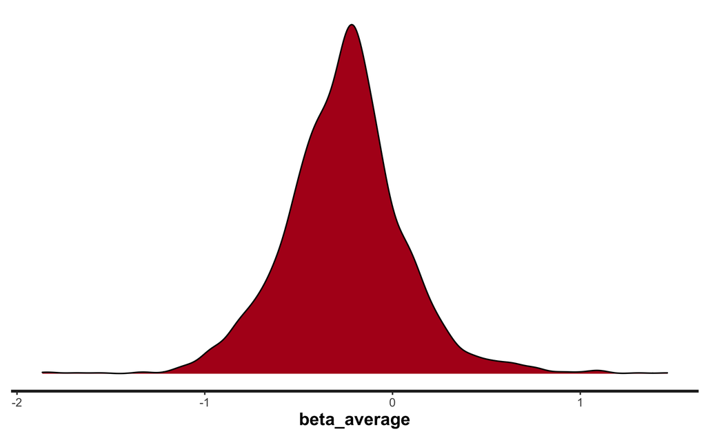

```r
stan_dens(fit_time, pars = c('beta_average'))
```

```r
beta_fit_time <- extract(fit_time, 'beta')[[1]]
```

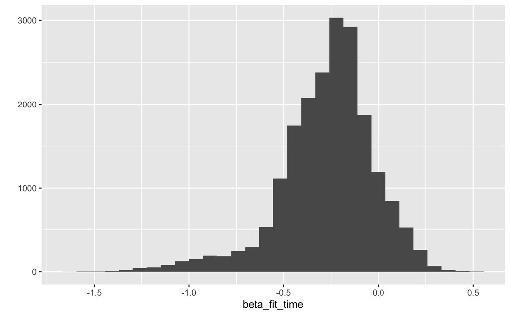

```r
qplot(beta_fit_time)
```

```r
quantile(extract(fit_time, pars = "beta_average")[[1]], probs = c(0.0, 0.5))
```

```
        0%        50%
-1.8652298 -0.2499519
```